# INFO634 - Group project

Below analysis has been done by Nadiia Nikoniuk

11/09/2021

## Introducation

The purpose of this report is:

- Statistics about the rollout of COVID-19 vaccines in New Zealand;
- COVID-19 vaccination projection for NZ.

I have used two datasource for this report.

The first datasource is the data provided by the Ministry of Health. Data file has been downloaded from the [Ministry of Health](https://www.health.govt.nz/our-work/diseases-and-conditions/covid-19-novel-coronavirus/covid-19-data-and-statistics/covid-19-vaccine-data) web site.

The second datasource is STANS NZ web site. To load data from STATS NZ I have used API.

## Statistics about the rollout of COVID-19 vaccines in New Zealand

```r
library("readxl")
Vaccin_DHB <- read_excel("covid_vaccinations_21_09_2021.xlsx", sheet = "DHBofResidence by ethnicity")
```

```
## * `` -> ...10
```

```r
#drop last two columns
Vaccin_DHB<-Vaccin_DHB[-c(10,11)]
Vaccin_DHB$`DHB of residence`<-factor(Vaccin_DHB$`DHB of residence`)
Vaccin_DHB$`Age group`<-factor(Vaccin_DHB$`Age group`)
Vaccin_DHB$`Ethnic group`<-factor(Vaccin_DHB$`Ethnic group`)
Vaccin_DHB$`Gender`<-factor(Vaccin_DHB$`Gender`)
Vaccin_DHB
```

| DHB of residence | Ethnic group | Age group | Gender | First dose administered | Second dose administered | Population | First dose uptake per 1000 people | Second dose uptake per 1000 people |
| --- | --- | --- | --- | --- | --- | --- | --- | --- |
| Auckland Metro | Asian | 12-15 | Female | 8023 | 678 | 9507 | 844 | 71 |
| Auckland Metro | Asian | 12-15 | Male | 8450 | 711 | 10290 | 821 | 69 |
| Auckland Metro | Asian | 12-15 | Unknown/Other | 13 | 0 | 8 | 1625 | 250 |
| Auckland Metro | Asian | 16-19 | Female | 8283 | 2653 | 8658 | 957 | 306 |
| Auckland Metro | Asian | 16-19 | Male | 8631 | 2622 | 8838 | 977 | 297 |
| Auckland Metro | Asian | 16-19 | Unknown/Other | 76 | 35 | 20 | 3800 | 1750 |
| Auckland Metro | Asian | 20-24 | Female | 12101 | 5445 | 13119 | 922 | 415 |
| Auckland Metro | Asian | 20-24 | Male | 13069 | 4941 | 13140 | 995 | 376 |
| Auckland Metro | Asian | 20-24 | Unknown/Other | 144 | 49 | 26 | 5538 | 1885 |
| Auckland Metro | Asian | 25-29 | Female | 18058 | 8913 | 22261 | 811 | 400 |

[output cut: 2673 more lines]

### Summary table

```r
summary(Vaccin_DHB)
```

```
##                         DHB of residence            Ethnic group   Age group
##  Auckland Metro                 : 201    Asian            :577   30-34  : 183
##  Capital & Coast and Hutt Valley: 179    European or Other:637   25-29  : 181
##  Canterbury                     : 177    Maori            :580   35-39  : 181
##  Waikato                        : 175    Pacific Peoples  :517   40-44  : 176
##  Southern                       : 165    Unknown          :371   45-49  : 174
##  MidCentral                     : 163    Various          :  1   55-59  : 173
##  (Other)                        :1623                            (Other):1615
##            Gender     First dose administered Second dose administered
##  Female       :1307   Min.   :    5           Min.   :    0.0
##  Male         :1309   1st Qu.:   37           1st Qu.:   18.0
##  Unknown/Other:  66   Median :  194           Median :   85.0
##  Various      :   1   Mean   : 1173           Mean   :  622.8
##                       3rd Qu.:  838           3rd Qu.:  385.0
##                       Max.   :25502           Max.   :16518.0
##
##    Population      First dose uptake per 1000 people
##  Min.   :    5.0   Min.   :   27.0
##  1st Qu.:   47.5   1st Qu.:  621.0
##  Median :  239.0   Median :  833.0
##  Mean   : 1568.8   Mean   :  913.7
##  3rd Qu.: 1339.0   3rd Qu.:  953.0
##  Max.   :30226.0   Max.   :33333.0
##
##  Second dose uptake per 1000 people
##  Min.   :    0.0
##  1st Qu.:  209.5
##  Median :  477.0
##  Mean   :  520.9
##  3rd Qu.:  744.5
##  Max.   :17167.0
##
```

### DHB of Residence by ethnicity: Homogeniety

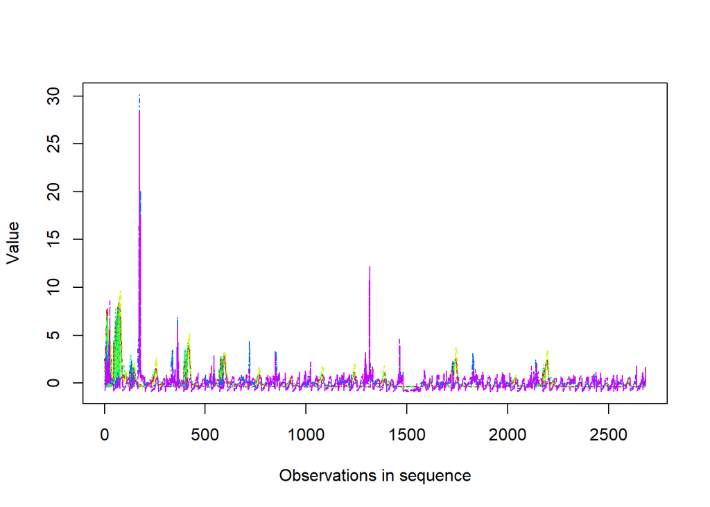

```r
cols <- c("First dose administered","Second dose administered","Population","First dose uptake per 1000 people","Second dose uptake per 1000 people") # choose the numeric columns
numData <- scale(Vaccin_DHB[,cols], center = TRUE, scale = TRUE)
matplot(numData, type = "l", col = rainbow(ncol(numData)), xlab = "Observations in sequence", ylab = "Value")
```

### DHB of Residence by ethnicity: : Explore dataset for a missing data

Plot the missing observations.

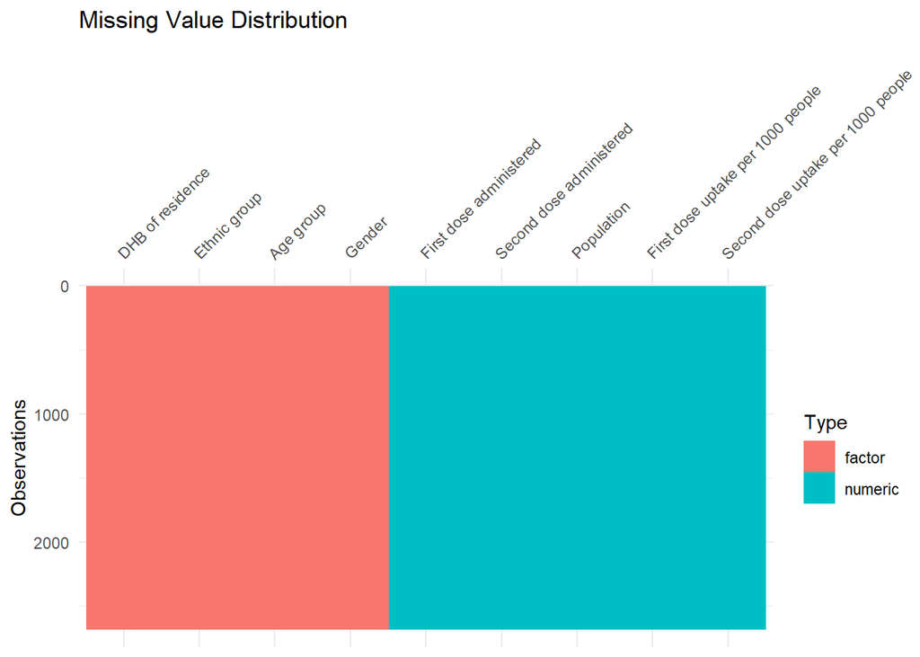

```r
library(visdat)
library(ggplot2)
vis_dat(Vaccin_DHB) + ggtitle("Missing Value Distribution")
```

There is no missing data in the dataset.

### Total Vaccinations

Lets start the report from showing the percentage of people received the first and second dose in NZ.

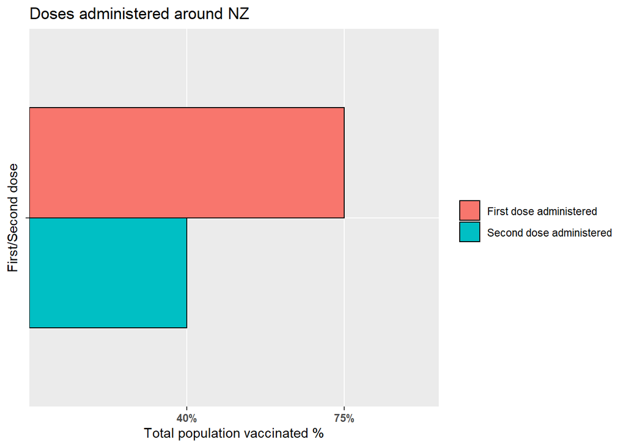

```r
library(scales)

Population=sum(Vaccin_DHB$`Population`)
Sum_first<-(percent(sum(Vaccin_DHB$`First dose administered`)/Population))
Sum_second<-(percent(sum(Vaccin_DHB$`Second dose administered`)/Population))
Label2<-c("First dose administered", "Second dose administered")
Vaccin<-c(Sum_first, Sum_second)
Vaccin_admin <- data.frame(Label2, Vaccin)



ggplot(Vaccin_admin, aes(x = "", y =Vaccin, fill =`Label2`)) +
  geom_bar(stat = "identity", color = "black",position = position_dodge(), width = 0.7)+
  theme(axis.text.x = element_text(face = "bold"),
  legend.title = element_blank()) +
  ggtitle("Doses administered around NZ")+
  coord_flip()+
  xlab("First/Second dose") +
  ylab("Total population vaccinated %")
```

**Definitions:**

**Cumulative total:** All vaccinations that have been administered and entered into the COVID-19 Immunisation Register up until midnight of the night before the data is published.

**Total population vaccinated %:** Vaccinations administered divided by HSU population estimates for the total population (0+).

Below we can see how each region performs with the Covid-19 vaccination around NZ.

```r
library(sf)
library(raster)
library(dplyr)
library(spData)
```

```r
#library(spDataLarge)
library(tmap)
library(dplyr)
data(nz, land)



Vaccin_DHB<-Vaccin_DHB %>%
  mutate(Name = case_when(
    grepl("Auckland Metro", as.character(`DHB of residence`)) ~ "Auckland",
    grepl("Bay of Plenty", as.character(`DHB of residence`)) ~ "Bay of Plenty",
    grepl("Canterbury", as.character(`DHB of residence`)) ~ "Canterbury",
    grepl("Capital & Coast and Hutt Valley", as.character(`DHB of residence`)) ~ "Wellington",
    grepl("Hawkes Bay", as.character(`DHB of residence`)) ~ "Hawke's Bay",
    grepl("Lakes", as.character(`DHB of residence`)) ~ "Bay of Plenty",
    grepl("MidCentral", as.character(`DHB of residence`)) ~ "Manawatu-Wanganui",
    grepl("Nelson Marlborough", as.character(`DHB of residence`)) ~ "Tasman",
    grepl("Northland", as.character(`DHB of residence`)) ~ "Northland",
    grepl("South Canterbury", as.character(`DHB of residence`)) ~ "Canterbury",
    grepl("Southern", as.character(`DHB of residence`)) ~ "Southland",
    grepl("Tairawhiti", as.character(`DHB of residence`)) ~ "Gisborne",
    grepl("Taranaki", as.character(`DHB of residence`)) ~ "Taranaki",
    grepl("Waikato", as.character(`DHB of residence`)) ~ "Waikato",
    grepl("Wairarapa", as.character(`DHB of residence`)) ~ "Wellington",
    grepl("West Coast", as.character(`DHB of residence`)) ~ "West Coast",
    grepl("Whanganui", as.character(`DHB of residence`)) ~ "Manawatu-Wanganui"
    ))

Vaccin_DHB$Name<-factor(Vaccin_DHB$Name)
df101sum<-sum(Vaccin_DHB$`First dose administered`)

df101 = Vaccin_DHB%>%
  group_by(`Name`) %>%
  summarise(`First dose administered` = sum(`First dose administered`), 'First dose administered %'=100* (sum(`First dose administered`)/sum(Population)), 'First dose administered % '= percent(sum(`First dose administered`)/sum(Population)))%>%
  mutate(New_Var = paste0(`Name`))


nz <- left_join(nz, df101, by = "Name", all=TRUE)


df101a = Vaccin_DHB%>%
  group_by(`Name`) %>%
  summarise(`Second dose administered` = sum(`Second dose administered`), 'Second dose administered %'=100* (sum(`Second dose administered`)/sum(Population)),'Second dose administered % '= percent(sum(`Second dose administered`)/sum(Population)))%>%
  mutate(New_Var = paste0(`Name`))

nz <- left_join(nz, df101a, by = "Name", all=TRUE)


nz$`First dose administered_adj` <- as.character(formatC(nz$`First dose administered`,
                                           big.mark = " ",
                                           format = "f",
                                           digits = 0))
nz$`Second dose administered_adj` <- as.character(formatC(nz$`Second dose administered`,
                                           big.mark = " ",
                                           format = "f",
                                           digits = 0))

nz<-nz %>%
  mutate('First dose administered_adj' = case_when(
    grepl("NA", as.character(`First dose administered_adj`)) ~ "",
    TRUE ~ as.character(`First dose administered_adj`)
   ))

nz<-nz %>%
  mutate('Second dose administered_adj' = case_when(
    grepl("NA", as.character(`Second dose administered_adj`)) ~ "",
    TRUE ~ as.character(`Second dose administered_adj`)
   ))

tmap_mode("plot")
```

```
## tmap mode set to plotting
```

```
## Legend labels were too wide. Therefore, legend.text.size has been set to 0.4. Increase legend.width (argument of tm_layout) to make the legend wider and therefore the labels larger.
```

```
## Legend labels were too wide. Therefore, legend.text.size has been set to 0.38. Increase legend.width (argument of tm_layout) to make the legend wider and therefore the labels larger.
```

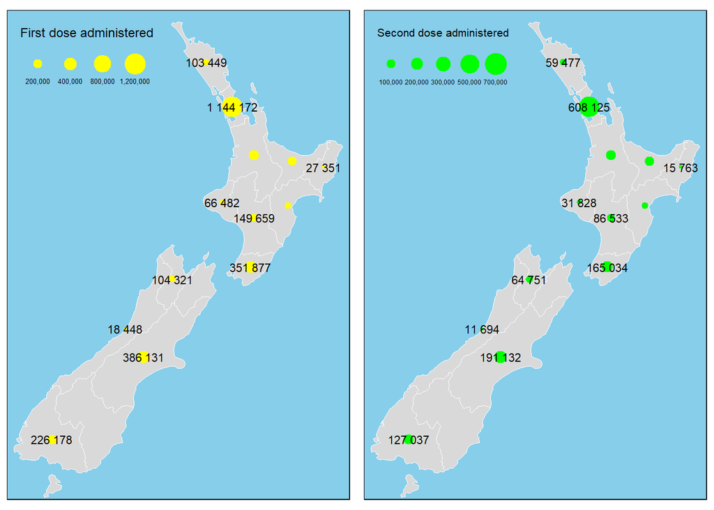

```r
## tmap mode set to plotting
tm1<-tm_shape(nz) +
tm_fill() +
tm_bubbles(size="First dose administered", col="yellow", size.lim=c(0, 2e7),  border.col = "yellow")+
  tm_borders("white", lwd = .5) +
  tm_layout(bg.color = "skyblue", inner.margins = c(0, .02, .02, .02))+
  tm_text(text = "First dose administered_adj", size = 0.7, remove.overlap = TRUE )


tm2 <-tm_shape(nz) +
tm_fill() +
tm_bubbles(size="Second dose administered", col="green", size.lim=c(0, 2e7), border.col = "green")+
  tm_borders("white", lwd = .5) +
  tm_layout(bg.color = "skyblue", inner.margins = c(0, .02, .02, .02))+
  tm_text(text = "Second dose administered_adj", size = 0.7, remove.overlap = TRUE)

tmap_arrange(tm1, tm2)
```

```r
tmap_mode("plot")
```

```
## tmap mode set to plotting
```

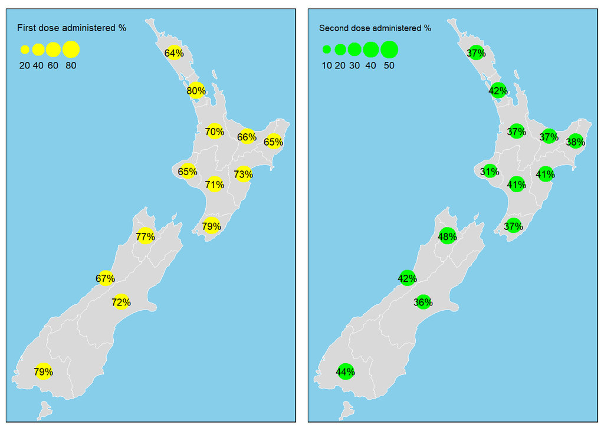

```r
## tmap mode set to plotting
tm2<-tm_shape(nz) +
tm_fill() +
tm_bubbles(size="First dose administered %", col="yellow", size.lim=c(0, 2e7), border.col = "yellow")+
  tm_borders("white", lwd = .5) +
  tm_layout(bg.color = "skyblue", inner.margins = c(0, .02, .02, .02))+
  tm_text(text = "First dose administered % ", size = 0.7, remove.overlap = TRUE )


tm3 <-tm_shape(nz) +
tm_fill() +
tm_bubbles(size="Second dose administered %", col="green", size.lim=c(0, 2e7), border.col = "green")+
  tm_borders("white", lwd = .5) +
  tm_layout(bg.color = "skyblue", inner.margins = c(0, .02, .02, .02))+
  tm_text(text = "Second dose administered % ", size = 0.7, remove.overlap = TRUE)

tmap_arrange(tm2, tm3)
```

### Novelties

In this section I will explore the dataset for ourtliers.

### Outliers by DHB

To keep the dataset clear I will remove the rows with the various or unknown data: - DHB of residence - ‘Various’, ‘Overseas / Unknown’; - Ethnic group - ‘Unknown’ and ‘Various’; - Age group - ‘Various’; - Gender - ‘Unknown/Other’, ‘Various’;

```r
Vaccin_DHB<-filter(Vaccin_DHB,
                    Vaccin_DHB$`DHB of residence`!="Various",
                    Vaccin_DHB$`DHB of residence`!="Overseas / Unknown",
                    Vaccin_DHB$`Ethnic group`!="Unknown",
                    Vaccin_DHB$`Ethnic group`!="Various",
                    Vaccin_DHB$`Age group`!="Various",
                    Vaccin_DHB$Gender!="Unknown/Other",
                    Vaccin_DHB$Gender!="Various")
```

Some DHBs have over 1000 vaccinated people per 1000 population because people from another DHBs can be vaccinated there. We decided to adjust all values over 1000 to 1000.

```r
Vaccin_DHB$`First dose uptake per 1000 people`[Vaccin_DHB$`First dose uptake per 1000 people` >1000] <- 1000
Vaccin_DHB$`Second dose uptake per 1000 people`[Vaccin_DHB$`Second dose uptake per 1000 people` >1000] <- 1000
```

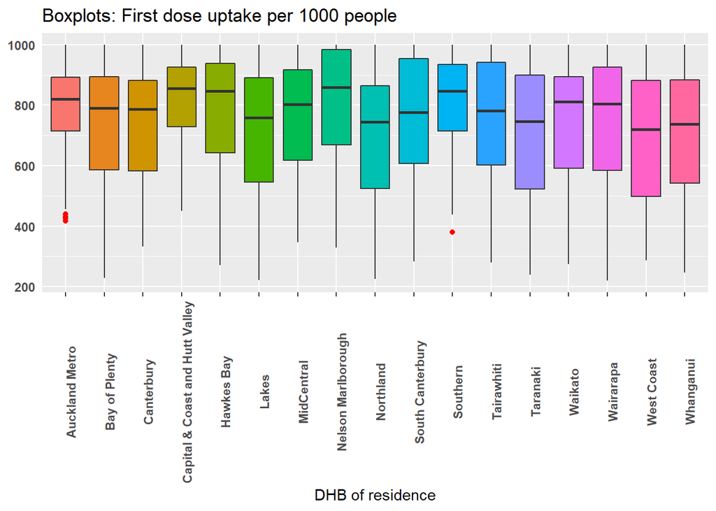

```r
ggplot(data = Vaccin_DHB, aes(x=`DHB of residence`, y=`First dose uptake per 1000 people`)) +
geom_boxplot(aes(fill=`DHB of residence`), outlier.colour = "red")+
#ggrepel::geom_label_repel() +
labs(title = paste("Boxplots: First dose uptake per 1000 people"))+
theme(axis.title.y = element_blank(), axis.text.y = element_text(face = "bold"), axis.ticks.y = element_blank(), axis.text.x = element_text(face = "bold",angle = 90))+
theme(legend.position="down")
```

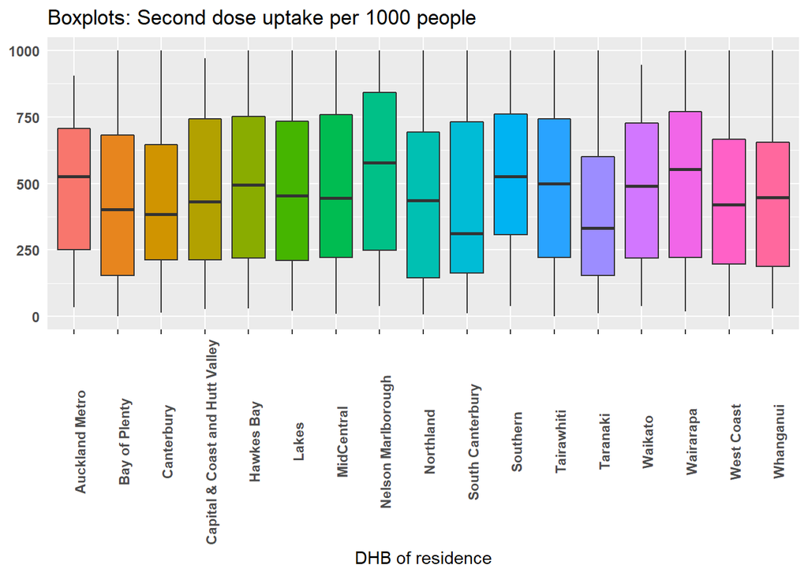

```r
ggplot(data = Vaccin_DHB, aes(x=`DHB of residence`, y=`Second dose uptake per 1000 people`)) +
geom_boxplot(aes(fill=`DHB of residence`), outlier.colour = "red")+
labs(title = paste("Boxplots: Second dose uptake per 1000 people"))+
theme(axis.title.y = element_blank(), axis.text.y = element_text(face = "bold"), axis.ticks.y = element_blank(), axis.text.x = element_text(face = "bold",angle = 90))+
theme(legend.position="down")
```

### Outliers by Age Group

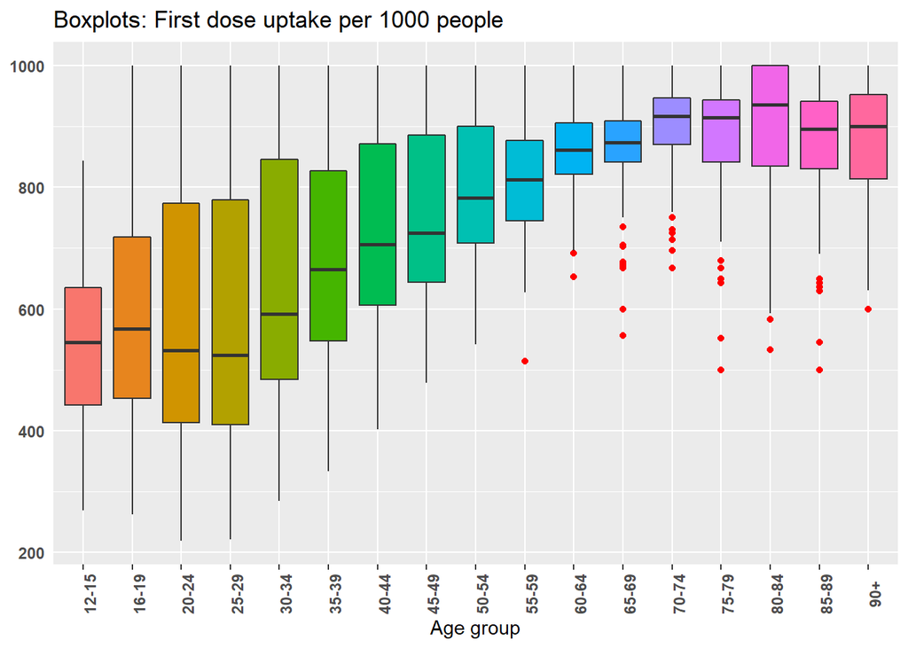

```r
library(ggrepel)
ggplot(data = Vaccin_DHB, aes(x=`Age group`, y=`First dose uptake per 1000 people`)) +
geom_boxplot(aes(fill=`Age group`), outlier.colour = "red")+
labs(title = paste("Boxplots: First dose uptake per 1000 people"))+
theme(axis.title.y = element_blank(), axis.text.y = element_text(face = "bold"), axis.ticks.y = element_blank(), axis.text.x = element_text(face = "bold",angle = 90))+
theme(legend.position="down")
```

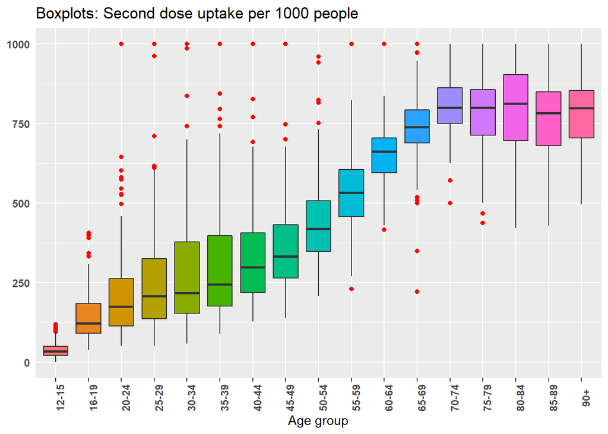

```r
library(ggrepel)
ggplot(data = Vaccin_DHB, aes(x=`Age group`, y=`Second dose uptake per 1000 people`)) +
geom_boxplot(aes(fill=`Age group`), outlier.colour = "red")+
labs(title = paste("Boxplots: Second dose uptake per 1000 people"))+
theme(axis.title.y = element_blank(), axis.text.y = element_text(face = "bold"), axis.ticks.y = element_blank(), axis.text.x = element_text(face = "bold",angle = 90))+
  theme(legend.position="down")
```

## DHB of Residence by ethnicity: Data overview

To simplify visualisation I have decided to reduce the Age group cardinality from 18 to 8 via merging different Age Groups.

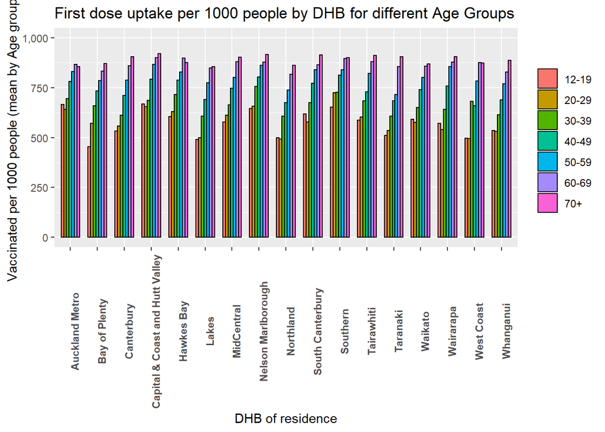

```r
library(dplyr)
Vaccin_DHB<-Vaccin_DHB %>%
  mutate(Age_Group_min = case_when(
    grepl("12-15", as.character(`Age group`)) ~ "12-19",
    grepl("16-19", as.character(`Age group`)) ~ "12-19",
    grepl("20-24", as.character(`Age group`)) ~ "20-29",
    grepl("25-29", as.character(`Age group`)) ~ "20-29",
    grepl("30-34", as.character(`Age group`)) ~ "30-39",
    grepl("35-39", as.character(`Age group`)) ~ "30-39",
    grepl("40-44", as.character(`Age group`)) ~ "40-49",
    grepl("45-49", as.character(`Age group`)) ~ "40-49",
    grepl("50-54", as.character(`Age group`)) ~ "50-59",
    grepl("55-59", as.character(`Age group`)) ~ "50-59",
    grepl("60-64", as.character(`Age group`)) ~ "60-69",
    grepl("65-69", as.character(`Age group`)) ~ "60-69",
    grepl("70-74", as.character(`Age group`)) ~ "70+",
    grepl("75-79", as.character(`Age group`)) ~ "70+",
    grepl("80-84", as.character(`Age group`)) ~ "70+",
    grepl("85-89", as.character(`Age group`)) ~ "70+",
    grepl("90+", as.character(`Age group`)) ~ "70+",
    grepl("Various", as.character(`Age group`)) ~ "Various"
    ))

Vaccin_DHB$Age_Group_min<-factor(Vaccin_DHB$Age_Group_min)

library(ggplot2)
library(dplyr)

df1 = Vaccin_DHB%>%
  group_by(`DHB of residence`,`Age_Group_min`) %>%
  summarise(Mean = mean(`First dose uptake per 1000 people`)) %>%
  mutate(New_Var = paste0(`DHB of residence`))
ggplot(df1, aes(x = New_Var, y = Mean, fill = `Age_Group_min`)) +
  geom_bar(stat = "identity", color = "black",position = position_dodge(), width = 0.7)+
  theme(axis.text.x = element_text(face = "bold",angle = 90),
  legend.title = element_blank()) +
  ggtitle("First dose uptake per 1000 people by DHB for different Age Groups")+
  xlab("DHB of residence") +
  ylab("Vaccinated per 1000 people (mean by Age group)")+
  scale_y_continuous(labels = scales::comma,limits=c(0,1000))
```

```r
df2 = Vaccin_DHB%>%
  group_by(`DHB of residence`,`Age_Group_min`) %>%
  summarise(Mean = mean(`Second dose uptake per 1000 people`)) %>%
  mutate(New_Var = paste0(`DHB of residence`))
```

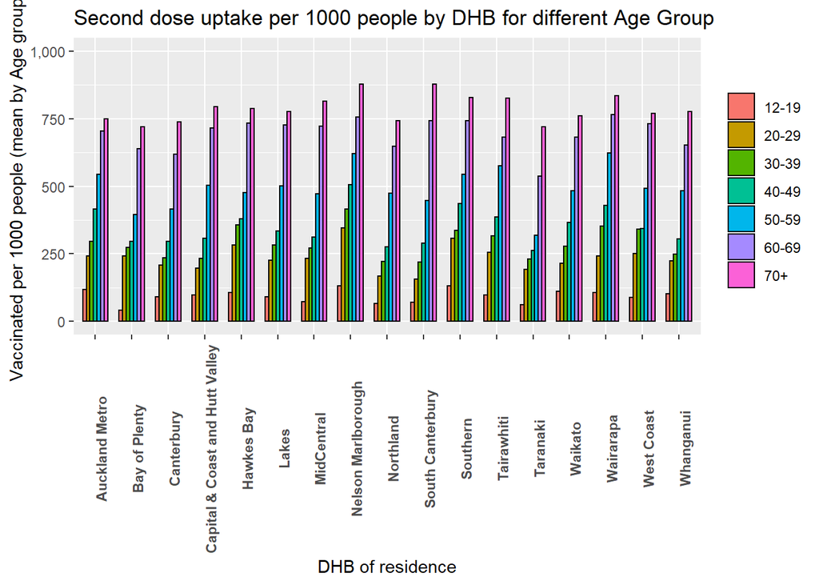

```r
ggplot(df2, aes(x = New_Var, y = Mean, fill = `Age_Group_min`)) +
  geom_bar(stat = "identity", color = "black",position = position_dodge(), width = 0.7)+
  theme(axis.text.x = element_text(face = "bold",angle = 90),
  legend.title = element_blank()) +
  ggtitle("Second dose uptake per 1000 people by DHB for different Age Group")+
  xlab("DHB of residence") +
  ylab("Vaccinated per 1000 people (mean by Age group)")+
  scale_y_continuous(labels = scales::comma,limits=c(0,1000))
```

```r
df11 = Vaccin_DHB%>%
  group_by(`DHB of residence`,`Ethnic group`) %>%
  summarise(Mean = mean(`First dose uptake per 1000 people`)) %>%
  mutate(New_Var = paste0(`DHB of residence`))
```

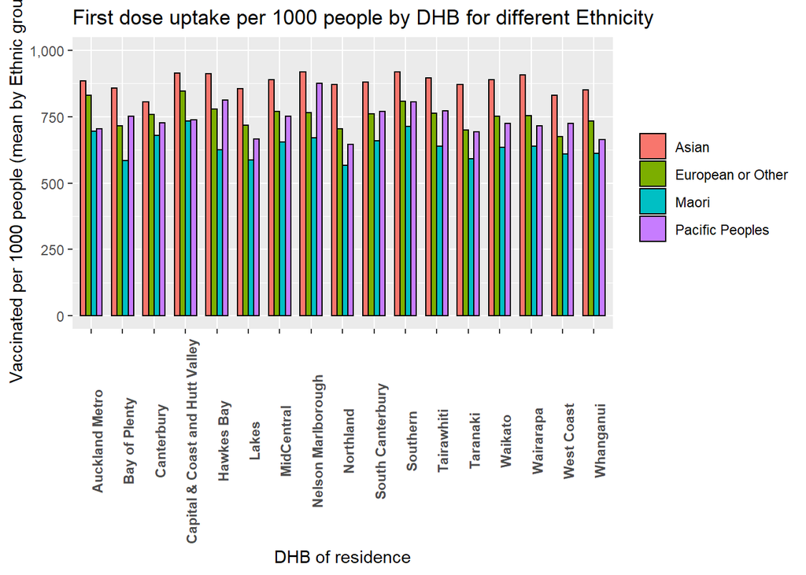

```r
ggplot(df11, aes(x = New_Var, y = Mean, fill = `Ethnic group`)) +
  geom_bar(stat = "identity", color = "black",position = position_dodge(), width = 0.7)+
  theme(axis.text.x = element_text(face = "bold",angle = 90),
  legend.title = element_blank()) +
  ggtitle("First dose uptake per 1000 people by DHB for different Ethnicity")+
  xlab("DHB of residence") +
  ylab("Vaccinated per 1000 people (mean by Ethnic group)")+
  scale_y_continuous(labels = scales::comma,limits=c(0,1000))
```

```r
df22 = Vaccin_DHB%>%
  group_by(`DHB of residence`,`Ethnic group`) %>%
  summarise(Mean = mean(`Second dose uptake per 1000 people`)) %>%
  mutate(New_Var = paste0(`DHB of residence`))
```

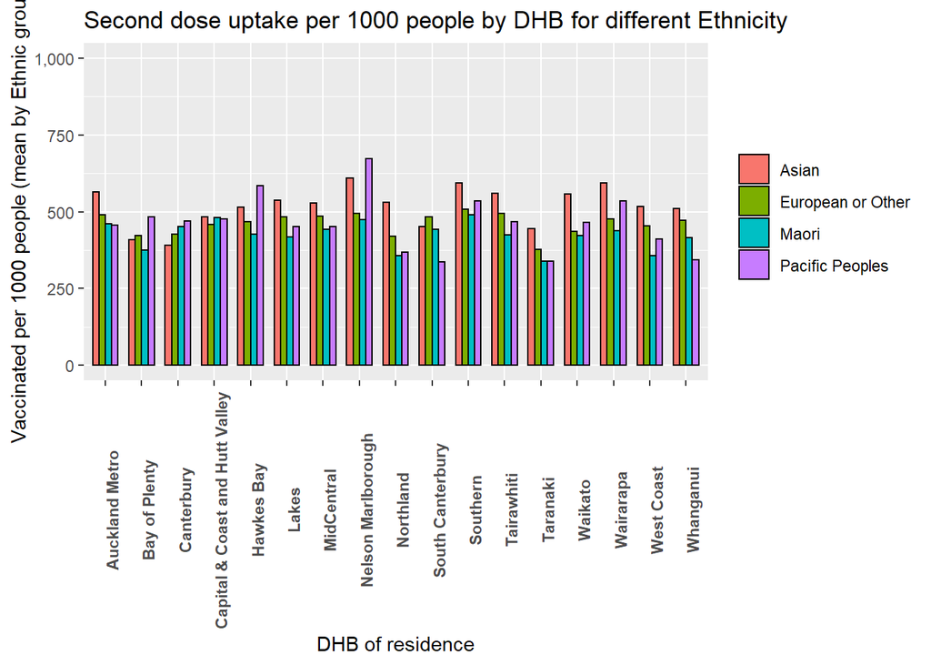

```r
ggplot(df22, aes(x = New_Var, y = Mean, fill = `Ethnic group`)) +
  geom_bar(stat = "identity", color = "black",position = position_dodge(), width = 0.7)+
  theme(axis.text.x = element_text(face = "bold",angle = 90),
  legend.title = element_blank()) +
  ggtitle("Second dose uptake per 1000 people by DHB for different Ethnicity")+
  xlab("DHB of residence") +
  ylab("Vaccinated per 1000 people (mean by Ethnic group)")+
  scale_y_continuous(labels = scales::comma,limits=c(0,1000))
```

```r
df3 = Vaccin_DHB%>%
  group_by(`Ethnic group`,`Age_Group_min`) %>%
  summarise(Mean = mean(`First dose uptake per 1000 people`)) %>%
  mutate(New_Var = paste0(`Ethnic group`))
```

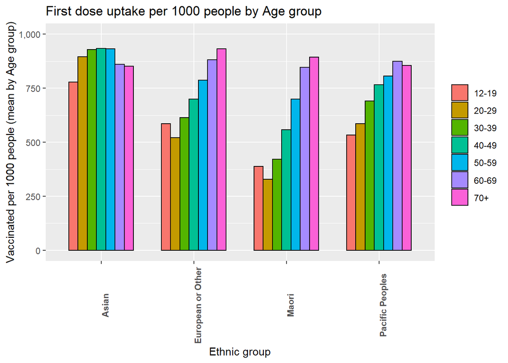

```r
ggplot(df3, aes(x = New_Var, y = Mean, fill = `Age_Group_min`)) +
  geom_bar(stat = "identity", color = "black",position = position_dodge(), width = 0.7)+
  theme(axis.text.x = element_text(face = "bold",angle = 90),
  legend.title = element_blank()) +
  ggtitle("First dose uptake per 1000 people by Age group")+
  xlab("Ethnic group") +
  ylab("Vaccinated per 1000 people (mean by Age group)")+
  scale_y_continuous(labels = scales::comma,limits=c(0,1000))
```

```r
df33 = Vaccin_DHB%>%
  group_by(`Ethnic group`,`Age_Group_min`) %>%
  summarise(Mean = mean(`Second dose uptake per 1000 people`)) %>%
  mutate(New_Var = paste0(`Ethnic group`))
```

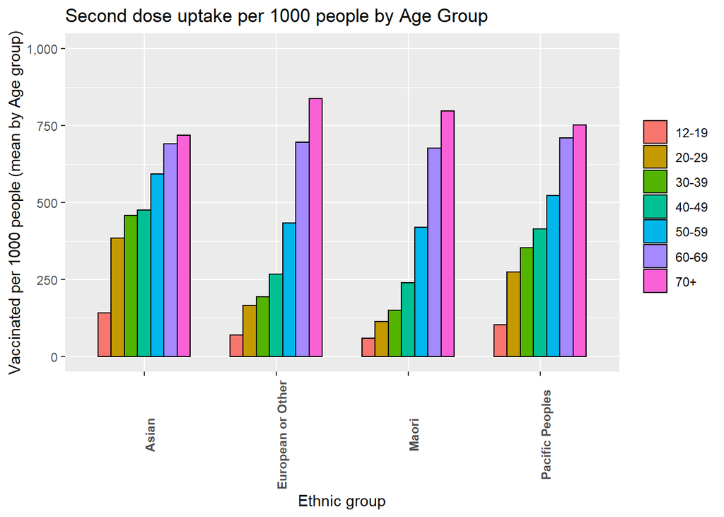

```r
ggplot(df33, aes(x = New_Var, y = Mean, fill = `Age_Group_min`)) +
  geom_bar(stat = "identity", color = "black",position = position_dodge(), width = 0.7)+
  theme(axis.text.x = element_text(face = "bold",angle = 90),
  legend.title = element_blank()) +
  ggtitle("Second dose uptake per 1000 people by Age Group")+
  xlab("Ethnic group") +
  ylab("Vaccinated per 1000 people (mean by Age group)")+
  scale_y_continuous(labels = scales::comma,limits=c(0,1000))
```

```r
df6 = Vaccin_DHB%>%
  group_by(`DHB of residence`,`Gender`) %>%
  summarise(Mean = mean(`First dose uptake per 1000 people`)) %>%
  mutate(New_Var = paste0(`DHB of residence`))
```

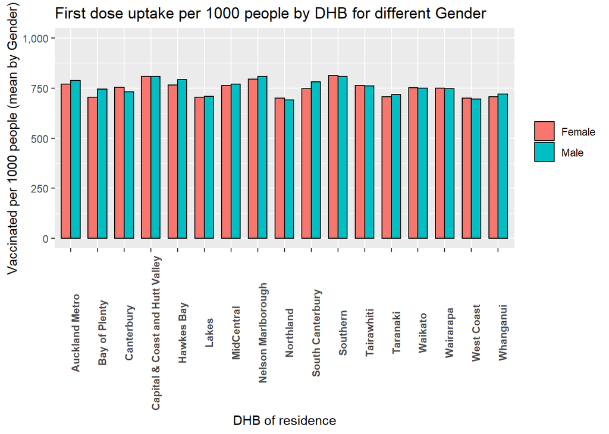

```r
ggplot(df6, aes(x = New_Var, y = Mean, fill = `Gender`)) +
  geom_bar(stat = "identity", color = "black",position = position_dodge(), width = 0.7)+
  theme(axis.text.x = element_text(face = "bold",angle = 90),
  legend.title = element_blank()) +
  ggtitle("First dose uptake per 1000 people by DHB for different Gender")+
  xlab("DHB of residence") +
  ylab("Vaccinated per 1000 people (mean by Gender)")+
  scale_y_continuous(labels = scales::comma,limits=c(0,1000))
```

```r
df66 = Vaccin_DHB%>%
  group_by(`DHB of residence`,`Gender`) %>%
  summarise(Mean = mean(`Second dose uptake per 1000 people`)) %>%
  mutate(New_Var = paste0(`DHB of residence`))
```

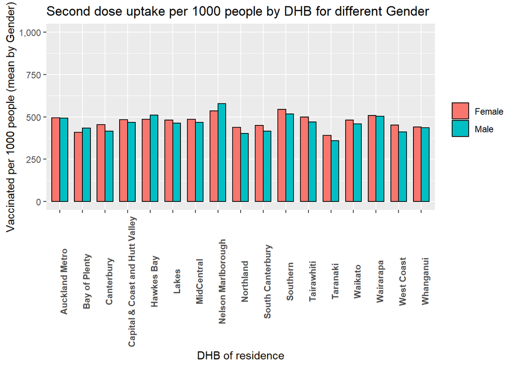

```r
ggplot(df66, aes(x = New_Var, y = Mean, fill =`Gender`)) +
  geom_bar(stat = "identity", color = "black",position = position_dodge(), width = 0.7)+
  theme(axis.text.x = element_text(face = "bold",angle = 90),
  legend.title = element_blank()) +
  ggtitle("Second dose uptake per 1000 people by DHB for different Gender")+
  xlab("DHB of residence") +
  ylab("Vaccinated per 1000 people (mean by Gender)")+
  scale_y_continuous(labels = scales::comma,limits=c(0,1000))
```

```r
df7 = Vaccin_DHB%>%
  group_by(`Ethnic group`,`Gender`) %>%
  summarise(Mean = mean(`First dose uptake per 1000 people`)) %>%
  mutate(New_Var = paste0(`Ethnic group`))
```

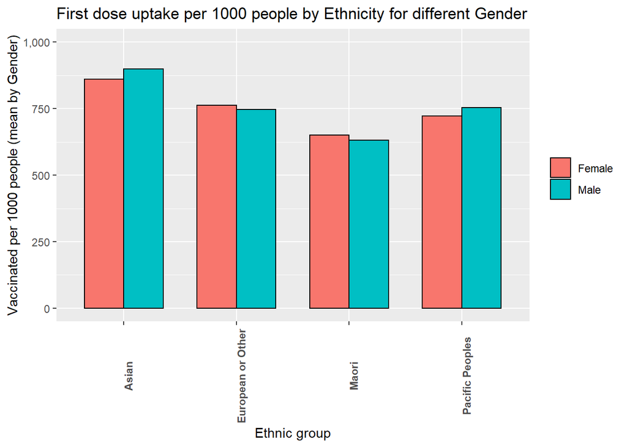

```r
ggplot(df7, aes(x = New_Var, y = Mean, fill = `Gender`)) +
  geom_bar(stat = "identity", color = "black",position = position_dodge(), width = 0.7)+
  theme(axis.text.x = element_text(face = "bold",angle = 90),
  legend.title = element_blank()) +
  ggtitle("First dose uptake per 1000 people by Ethnicity for different Gender")+
  xlab("Ethnic group") +
  ylab("Vaccinated per 1000 people (mean by Gender)")+
  scale_y_continuous(labels = scales::comma,limits=c(0,1000))
```

```r
df77 = Vaccin_DHB%>%
  group_by(`Ethnic group`,`Gender`) %>%
  summarise(Mean = mean(`Second dose uptake per 1000 people`), Sd = sd(`Second dose uptake per 1000 people`)) %>%
  mutate(New_Var = paste0(`Ethnic group`))
```

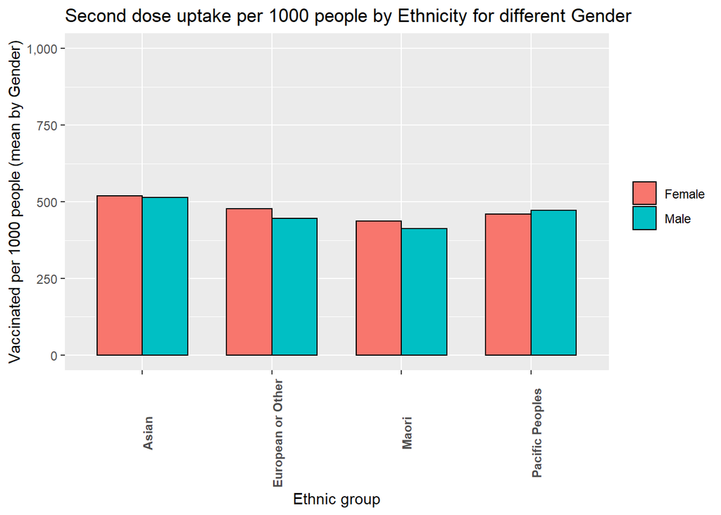

```r
ggplot(df77, aes(x = New_Var, y = Mean, fill =`Gender`)) +
  geom_bar(stat = "identity", color = "black",position = position_dodge(), width = 0.7)+
  theme(axis.text.x = element_text(face = "bold",angle = 90),
  legend.title = element_blank()) +
  ggtitle("Second dose uptake per 1000 people by Ethnicity for different Gender")+
  xlab("Ethnic group") +
  ylab("Vaccinated per 1000 people (mean by Gender)")+
  scale_y_continuous(labels = scales::comma,limits=c(0,1000))
```

```r
df8 = Vaccin_DHB%>%
  group_by(`Age group`,`Gender`) %>%
  summarise(Mean = mean(`First dose uptake per 1000 people`), Sd = sd(`First dose uptake per 1000 people`)) %>%
  mutate(New_Var = paste0(`Age group`))
```

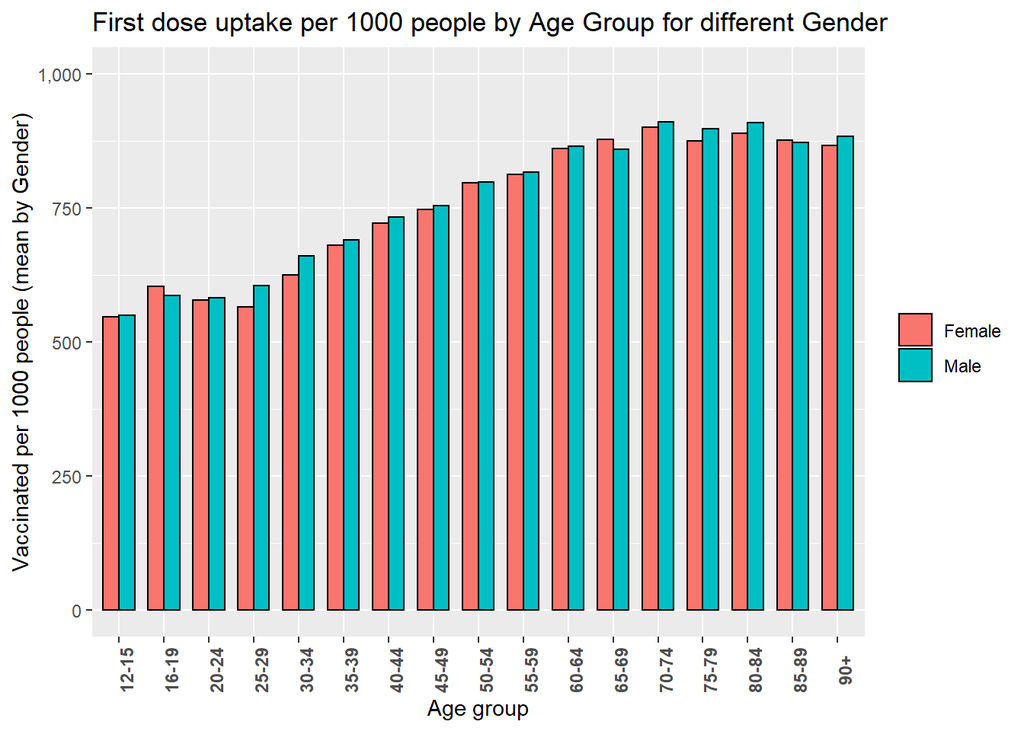

```r
ggplot(df8, aes(x = New_Var, y = Mean, fill = `Gender`)) +
  geom_bar(stat = "identity", color = "black",position = position_dodge(), width = 0.7)+
  theme(axis.text.x = element_text(face = "bold",angle = 90),
  legend.title = element_blank()) +
  ggtitle("First dose uptake per 1000 people by Age Group for different Gender")+
  xlab("Age group") +
  ylab("Vaccinated per 1000 people (mean by Gender)")+
  scale_y_continuous(labels = scales::comma,limits=c(0,1000))
```

```r
df88 = Vaccin_DHB%>%
  group_by(`Age group`,`Gender`) %>%
  summarise(Mean = mean(`Second dose uptake per 1000 people`), Sd = sd(`Second dose uptake per 1000 people`)) %>%
  mutate(New_Var = paste0(`Age group`))
```

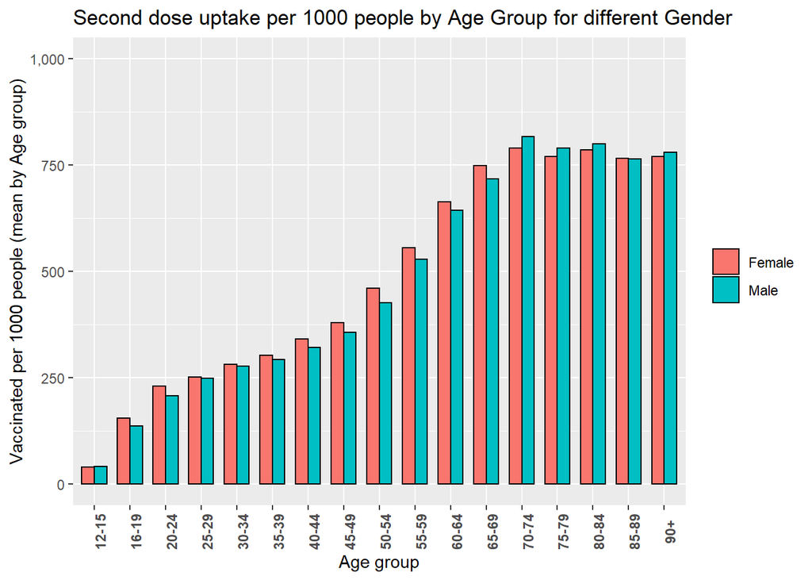

```r
ggplot(df88, aes(x = New_Var, y = Mean, fill =`Gender`)) +
  geom_bar(stat = "identity", color = "black",position = position_dodge(), width = 0.7)+
  theme(axis.text.x = element_text(face = "bold",angle = 90),
  legend.title = element_blank()) +

  ggtitle("Second dose uptake per 1000 people by Age Group for different Gender")+
  xlab("Age group") +
  ylab("Vaccinated per 1000 people (mean by Age group)")+
  scale_y_continuous(labels = scales::comma,limits=c(0,1000))
```

```r
library(scales)
df4sum<-sum(Vaccin_DHB$`First dose administered`)
df4 = Vaccin_DHB%>%
  group_by(`Ethnic group`) %>%
  summarise(Sum = sum(`First dose administered`), Labels=percent(sum(`First dose administered`)/ df4sum ), pop=sum(`Population`) )%>%
  mutate(New_Var = paste0(`Ethnic group`))

#remove values less than 1% as they are not significant
df4<-df4[which(df4$Labels>1),]
```

```r
df44sum<-sum(Vaccin_DHB$`Second dose administered`)
df44 = Vaccin_DHB%>%
  group_by(`Ethnic group`) %>%
  summarise(Sum = sum(`Second dose administered`), Labels=percent(sum(`Second dose administered`)/ df44sum ), pop=sum(`Population`) )%>%
  mutate(New_Var = paste0(`Ethnic group`))

#remove values less than 1% as they are not significant
df44<-df44[which(df44$Labels>1),]
```

```r
library(scales)
df4a = Vaccin_DHB%>%
  group_by(`Ethnic group`) %>%
  summarise(Sum = sum(`First dose administered`), pop=sum(`Population`) )%>%
  mutate(New_Var = paste0(`Ethnic group`))
```

```r
df44a = Vaccin_DHB%>%
  group_by(`Ethnic group`) %>%
  summarise(Sum = sum(`Second dose administered`), pop=sum(`Population`) )%>%
  mutate(New_Var = paste0(`Ethnic group`))
```

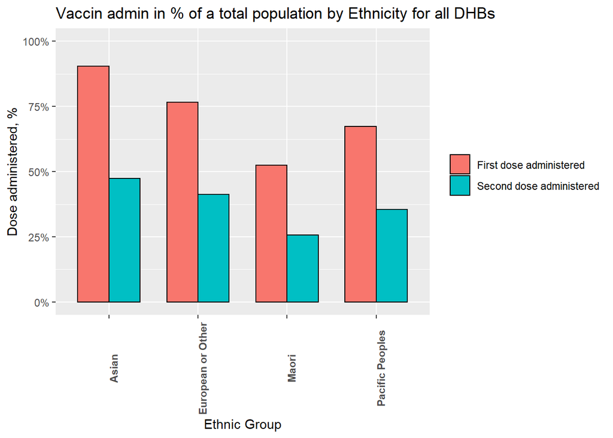

```r
df4a$name <-"First dose administered"
df44a$name <-"Second dose administered"
d<-rbind(df4a, df44a)

ggplot(d, aes(x = New_Var, y =Sum/pop, fill =`name`)) +
  geom_bar(stat = "identity", color = "black",position = position_dodge(), width = 0.7)+
  theme(axis.text.x = element_text(face = "bold",angle = 90),
  legend.title = element_blank()) +
  scale_y_continuous(labels=scales::percent, limits=c(0,1)) +
  ggtitle("Vaccin admin in % of a total population by Ethnicity for all DHBs")+
  xlab("Ethnic Group") +
  ylab("Dose administered, %")
```

```r
df5sum<-sum(Vaccin_DHB$`First dose administered`)
df5 = Vaccin_DHB%>%
  group_by(`Age_Group_min`) %>%
  summarise(Sum = sum(`First dose administered`), Labels=percent(sum(`First dose administered`)/ df5sum ) , pop=sum(`Population`))%>%
  mutate(New_Var = paste0(`Age_Group_min`))

#remove values less than 1% as they are not significant
df5<-df5[which(df5$Labels>1),]
```

```r
df55sum<-sum(Vaccin_DHB$`Second dose administered`)
df55 = Vaccin_DHB%>%
  group_by(`Age_Group_min`) %>%
  summarise(Sum = sum(`Second dose administered`), Labels=percent(sum(`Second dose administered`)/ df55sum ), pop=sum(`Population`) )%>%
  mutate(New_Var = paste0(`Age_Group_min`))

#remove values less than 1% as they are not significant
df55<-df55[which(df55$Labels>1),]
```

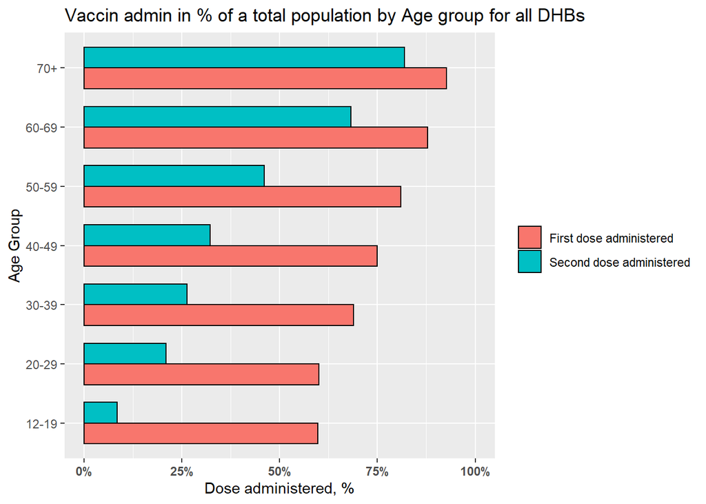

```r
df5$name <-"First dose administered"
df55$name <-"Second dose administered"
d<-rbind(df5, df55)

ggplot(d, aes(x = New_Var, y =Sum/pop, fill =`name`)) +
  geom_bar(stat = "identity", color = "black",position = position_dodge(), width = 0.7)+
  theme(axis.text.x = element_text(face = "bold"),
  legend.title = element_blank()) +
  scale_y_continuous(labels=scales::percent, limits=c(0,1)) +
  ggtitle("Vaccin admin in % of a total population by Age group for all DHBs")+
  xlab("Age Group") +
  ylab("Dose administered, %")+
  coord_flip()
```

```r
df9sum<-sum(Vaccin_DHB$`First dose administered`)
df9 = Vaccin_DHB%>%
  group_by(`Gender`) %>%
  summarise(Sum = sum(`First dose administered`), Labels=percent(sum(`First dose administered`)/ df9sum ), pop=sum(`Population`) )%>%
  mutate(New_Var = paste0(`Gender`))

#remove values less than 1% as they are not significant
df9<-df9[which(df9$Labels>1),]
```

```r
df99sum<-sum(Vaccin_DHB$`Second dose administered`)
df99 = Vaccin_DHB%>%
  group_by(`Gender`) %>%
  summarise(Sum = sum(`Second dose administered`), Labels=percent(sum(`Second dose administered`)/ df99sum ), pop=sum(`Population`) )%>%
  mutate(New_Var = paste0(`Gender`))

#remove values less than 1% as they are not significant
df99<-df99[which(df99$Labels>1),]
```

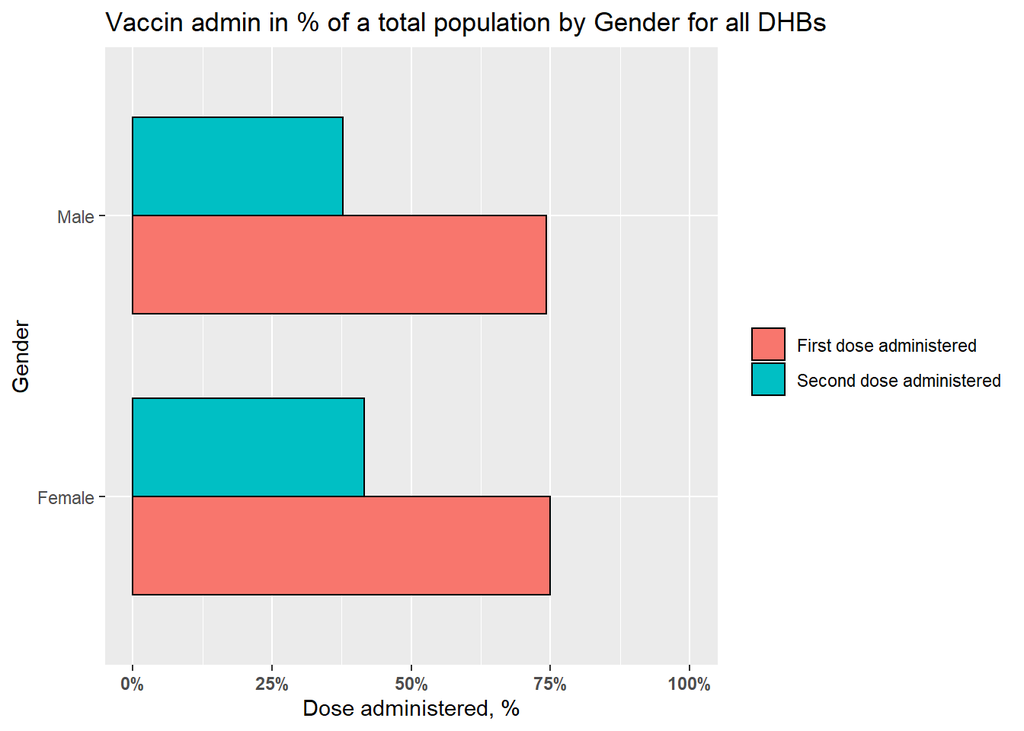

```r
df9$name <-"First dose administered"
df99$name <-"Second dose administered"
d<-rbind(df9, df99)

ggplot(d, aes(x = New_Var, y =Sum/pop, fill =`name`)) +
  geom_bar(stat = "identity", color = "black",position = position_dodge(), width = 0.7)+
  theme(axis.text.x = element_text(face = "bold"),
  legend.title = element_blank()) +
  scale_y_continuous(labels=scales::percent, limits=c(0,1)) +
  ggtitle("Vaccin admin in % of a total population by Gender for all DHBs")+
  xlab("Gender") +
  ylab("Dose administered, %")+
  coord_flip()
```

```r
library(scales)
df100 = Vaccin_DHB%>%
  group_by(`DHB of residence`) %>%
  summarise(Sum = sum(`First dose administered`), pop=sum(`Population`) )%>%
  mutate(New_Var = paste0(`DHB of residence`))
```

```r
library(scales)
df100a = Vaccin_DHB%>%
  group_by(`DHB of residence`) %>%
  summarise(Sum = sum(`Second dose administered`), pop=sum(`Population`) )%>%
  mutate(New_Var = paste0(`DHB of residence`))
```

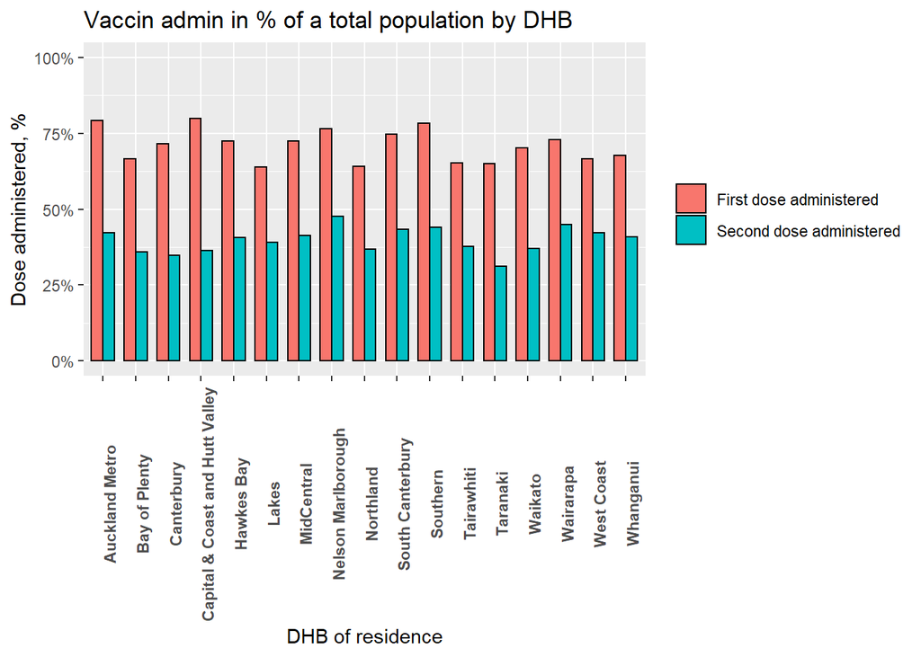

```r
df100$name <-"First dose administered"
df100a$name <-"Second dose administered"
d100<-rbind(df100, df100a)

ggplot(d100, aes(x = New_Var, y =Sum/pop, fill =`name`)) +
  geom_bar(stat = "identity", color = "black",position = position_dodge(), width = 0.7)+
  theme(axis.text.x = element_text(face = "bold",angle = 90),
  legend.title = element_blank()) +
  scale_y_continuous(labels=scales::percent, limits=c(0,1)) +
  ggtitle("Vaccin admin in % of a total population by DHB")+
  xlab("DHB of residence") +
  ylab("Dose administered, %")
```

## COVID-19 vaccination projection for NZ.

### Loading vaccinations data from STATS NZ using API

To load the data we have used API published by the Stats NZ.

Dataframe Observations_CPCOV10 contains the cumulative vaccination data around NZ.

**Cumulative total**: All vaccinations that have been administered and entered into the COVID-19 Immunisation Register up until midnight of the night before the data is published.

```r
source("get-opendata-catalogue-fun.R")
Catalogue <- get_odata_catalogue(
  service="https://api.stats.govt.nz/opendata/v1",
  endpoint="data.json",
  service_api_key = "3727dfa9d9f44874a510f426cd115b1c"
)


source("get-odata-fun.R")
Observations_CPCOV10<-  Filter(function(x)!all(is.na(x)),
                               get_odata(
                                 service = "https://api.stats.govt.nz/opendata/v1",
                                 endpoint = "Covid-19Indicators",
                                 entity = "Observations",
                                 query_option = "$filter=(
                                                    ResourceID eq 'CPCOV10'
                                                  )

                                          ",
                                 service_api_key = "3727dfa9d9f44874a510f426cd115b1c"))
```

```
##
 84 obs retrieved
```

```r
#Change Period to Date variable
library(lubridate)
library(DT)
library(tidyverse)
Observations_CPCOV10$Period<-as.Date(Observations_CPCOV10$Period, format="%Y-%m-%d")

#adding latest three date from the Ministry of Helath database as they are missingv - not done for presentation
Observations_CPCOV10 <- rbind(Observations_CPCOV10, c(1, "CPC0V10", "2021/09/05", "Cumulative vaccinations administered",3898365, "Number", "Cumulative Vaccinations", 0))
Observations_CPCOV10 <- rbind(Observations_CPCOV10, c(1, "CPC0V10", "2021/09/12", "Cumulative vaccinations administered",4329697, "Number", "Cumulative Vaccinations", 0))
Observations_CPCOV10 <- rbind(Observations_CPCOV10, c(1, "CPC0V10", "2021/09/19", "Cumulative vaccinations administered",4712992, "Number", "Cumulative Vaccinations", 0))

Observations_CPCOV10 <- rbind(Observations_CPCOV10, c(1, "CPC0V10", "2021/09/05", "Cumulative vaccine stock received",4630860, "Number", "Cumulative Vaccinations", 0))
Observations_CPCOV10 <- rbind(Observations_CPCOV10, c(1, "CPC0V10", "2021/09/12", "Cumulative vaccine stock received",5228730, "Number", "Cumulative Vaccinations", 0))
Observations_CPCOV10 <- rbind(Observations_CPCOV10, c(1, "CPC0V10", "2021/09/19", "Cumulative vaccine stock received",5729490, "Number", "Cumulative Vaccinations", 0))

#Change Value and Periond_Num variables to numeric
Observations_CPCOV10$Value<-as.numeric(Observations_CPCOV10$Value)

#create a dummy numeric variable from the date for Polynomial Regression model
Observations_CPCOV10$Period_Num<-as.numeric(Observations_CPCOV10$Period)


#Change Label1 variable to factor
Observations_CPCOV10$Label1<-factor(Observations_CPCOV10$Label1)
```

### Cumulative vaccination dataset analisys

### Cumulative vaccination: Data overview

Plot the dataset using ‘ggplot’ function

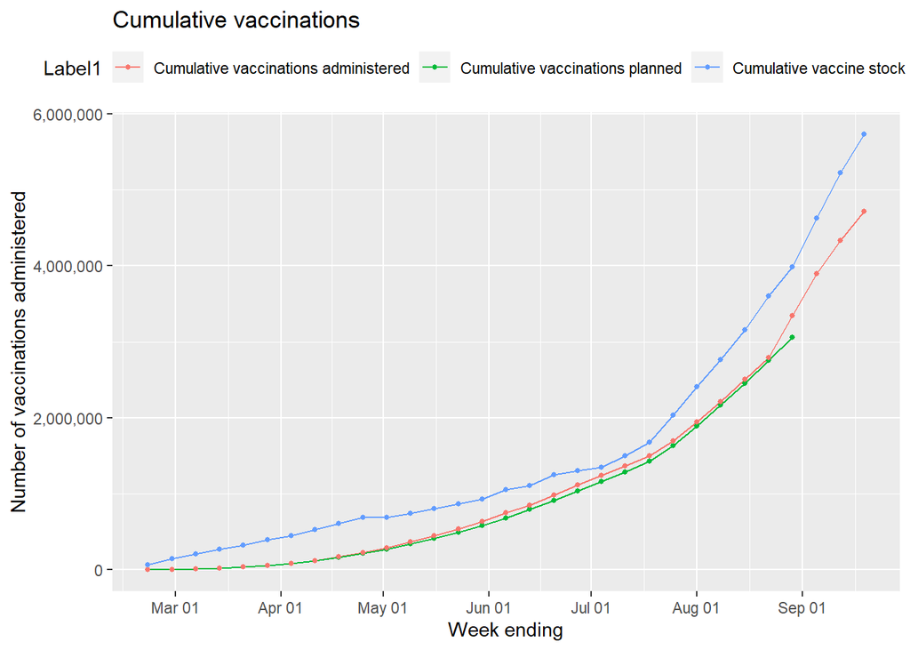

```r
library(ggplot2)
ggplot(Observations_CPCOV10, aes(x=Period, y = Value, group=Label1, colour=Label1)) +
  geom_line() +
  geom_point(size = 1)+
  ggtitle("Cumulative vaccinations")+
  xlab("Week ending") +
  ylab("Number of vaccinations administered")+
  labs(fill = "1")+
  theme(legend.position="top")+
  scale_y_continuous(labels = scales::comma)+
  scale_x_date(date_labels = "%b %d", date_breaks = "1 month")
```

There are some inconsistency in Cumulative vaccine stock data between June and August.

### Data table

```r
Observations_CPCOV10
```

| id | ResourceID | Period | Label1 | Value | Unit | Measure | Multiplier | Period_Num |
| --- | --- | --- | --- | --- | --- | --- | --- | --- |
| c41aac6b-3f41-4de9-8699-336875124e98 | CPCOV10 | 2021-02-21 | Cumulative vaccinations planned | 0 | Number | Cumulative Vaccinations | 0 | 18679 |
| a3f2414a-db61-4514-8dde-4743424caa4c | CPCOV10 | 2021-02-28 | Cumulative vaccinations planned | 4491 | Number | Cumulative Vaccinations | 0 | 18686 |
| de4cb5ba-cc26-476c-9b35-2126a94e9406 | CPCOV10 | 2021-03-07 | Cumulative vaccinations planned | 14420 | Number | Cumulative Vaccinations | 0 | 18693 |
| 296e24ce-bbd0-4ce0-899c-dbcbb54bdf6c | CPCOV10 | 2021-03-21 | Cumulative vaccinations planned | 35595 | Number | Cumulative Vaccinations | 0 | 18707 |
| 6ae651e6-403d-40bc-a594-d6252cbf9063 | CPCOV10 | 2021-03-14 | Cumulative vaccinations planned | 21715 | Number | Cumulative Vaccinations | 0 | 18700 |
| d322f403-fdce-443c-b907-0a0cf83267cb | CPCOV10 | 2021-03-28 | Cumulative vaccinations planned | 56290 | Number | Cumulative Vaccinations | 0 | 18714 |
| 3897260d-0f16-4b14-8265-f5408a5d4815 | CPCOV10 | 2021-04-04 | Cumulative vaccinations planned | 84595 | Number | Cumulative Vaccinations | 0 | 18721 |
| 65fc2efd-2c7c-4d2f-b72d-b1b3d21d60be | CPCOV10 | 2021-04-11 | Cumulative vaccinations planned | 117992 | Number | Cumulative Vaccinations | 0 | 18728 |
| 674fc6c5-817e-4b9d-9db0-db79b2f2a71c | CPCOV10 | 2021-04-18 | Cumulative vaccinations planned | 164107 | Number | Cumulative Vaccinations | 0 | 18735 |
| a429ef34-a530-4f1a-8216-8c762ba3178b | CPCOV10 | 2021-04-25 | Cumulative vaccinations planned | 216158 | Number | Cumulative Vaccinations | 0 | 18742 |

[output cut: 80 more lines]

### Summary table

```r
summary(Observations_CPCOV10)
```

```
##       id             ResourceID            Period
##  Length:90          Length:90          Min.   :2021-02-21
##  Class :character   Class :character   1st Qu.:2021-04-11
##  Mode  :character   Mode  :character   Median :2021-06-02
##                                        Mean   :2021-06-02
##                                        3rd Qu.:2021-07-25
##                                        Max.   :2021-09-19
##                                   Label1       Value             Unit
##  Cumulative vaccinations administered:31   Min.   :      0   Length:90
##  Cumulative vaccinations planned     :28   1st Qu.: 237800   Class :character
##  Cumulative vaccine stock received   :31   Median : 800156   Mode  :character
##                                            Mean   :1253751
##                                            3rd Qu.:1689161
##                                            Max.   :5729490
##    Measure           Multiplier          Period_Num
##  Length:90          Length:90          Min.   :18679
##  Class :character   Class :character   1st Qu.:18728
##  Mode  :character   Mode  :character   Median :18781
##                                        Mean   :18781
##                                        3rd Qu.:18833
##                                        Max.   :18889
```

### Cumulative vaccination: Explore dataset for a missing data

For a dataset, it is important to be able to answer these questions about missing values.

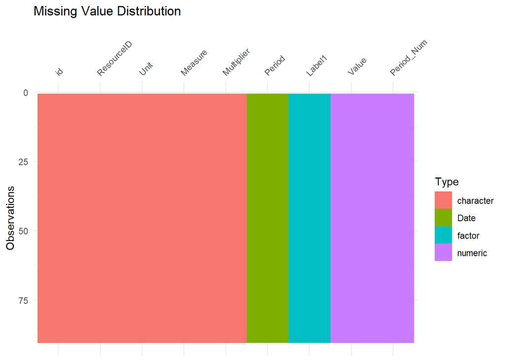

```r
library(visdat)
library(ggplot2)
vis_dat(Observations_CPCOV10) + ggtitle("Missing Value Distribution")
```

As per above there is no missing data detected in the dataset.

### Cumulative vaccination: Novelties

Box plot allows to identify outliers for a numeric data. Our data is cumulative and the latest observations are treated as outliers. This is why we can see some outliers on the box plot.

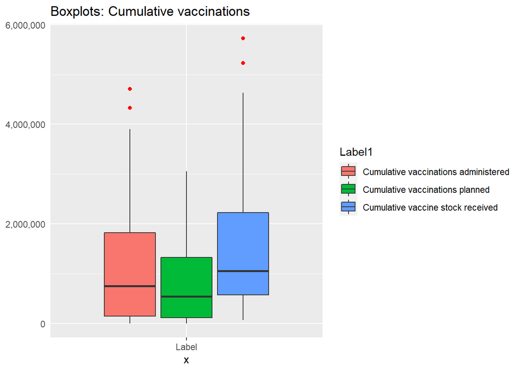

```r
ggplot(data = Observations_CPCOV10, aes(x="Label", y=Value)) + geom_boxplot(aes(fill=Label1), outlier.colour = "red")+
labs(title = paste("Boxplots: Cumulative vaccinations"))+
  theme(axis.title.y = element_blank(), axis.text.y = element_text(), axis.ticks.y = element_blank())+
  scale_y_continuous(labels = scales::comma)
```

### Cumulative vaccination: Split data by testing and trainign dataset

To evaluate the method performance we should split the dataset by testing and training. The first 80% of data is assigned to a training and the last 20% is assigned to a testing dataset. We will train our methods using training dataset and find the optimal hyper parameters for our model. The model with the optimal hyperparameters will be applied to the testing dataset.

```r
#separate "Cumulative vaccinations administered" observations as we are going to do a projection just for "Cumulative vaccinations administered"
vaccin_adm<-Observations_CPCOV10[which(Observations_CPCOV10$Label1=="Cumulative vaccinations administered"),] #
#split the data by training and testin
d<-1:(nrow(vaccin_adm)*0.8)
train<-vaccin_adm[d,]
test<-vaccin_adm[-d,]

#order the dataframe by date
train<-train[order(train$Period),]
test<-test[order(test$Period),]
```

### Cumulative vaccination: Vaccination forecast using SVM method

The first method I selected is SVM. Lets check how it performs.

```r
library(e1071)
library(Metrics)

#train with hyperparameter tuning
tuneResultsvm <- tune(svm, Value ~ Period,  data = train, kernel = "polynomial",
              ranges = list(gamma=2^(-1:1), epsilon = seq(0,1,0.1), cost = 2^(seq(0.5,10,.5))))



summary(tuneResultsvm$best.model)
```

```
##
## Call:
## best.tune(method = svm, train.x = Value ~ Period, data = train, ranges = list(gamma = 2^(-1:1),
##     epsilon = seq(0, 1, 0.1), cost = 2^(seq(0.5, 10, 0.5))), kernel = "polynomial")
##
##
## Parameters:
##    SVM-Type:  eps-regression
##  SVM-Kernel:  polynomial
##        cost:  8
##      degree:  3
##       gamma:  0.5
##      coef.0:  0
##     epsilon:  0.6
##
##
## Number of Support Vectors:  7
```

```r
#best model selection
tunedVals <-tuneResultsvm$best.model

#best parameters selection
tunePar<-tuneResultsvm$best.parameters
gammaBest<-tunePar$gamma
epsilonBest<-tunePar$epsilon
costBest<-tunePar$cost

#testing using the best model
predictYsvm <- predict(tunedVals, test)
```

### Cumulative vaccination: SVM model performance

```r
library(Metrics)
#errors
RMSE_svm<-rmse(test$Value, predictYsvm)
MAE_svm<-mae(test$Value, predictYsvm)
RSE_svm<-1-rse(test$Value, predictYsvm)

#creating error table
Measurement<-c("RMSE", "R-squared", "MAE")
err_Value<-c(round(RMSE_svm,2), round(RSE_svm,2), round(MAE_svm,2))
employ.data <- data.frame(Measurement, err_Value)
employ.data
```

| Measurement | err_Value |
| --- | --- |
| RMSE | 338439.38 |
| R-squared | 0.87 |
| MAE | 320316.72 |

We can plot the predicted and testing values to see how our model behaves.

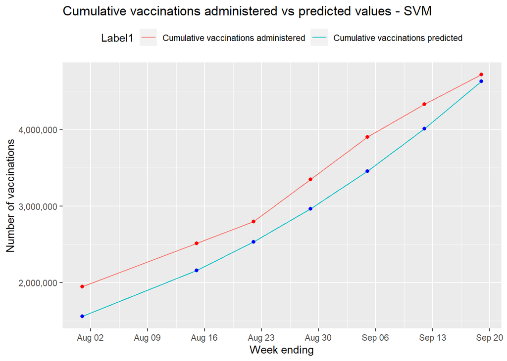

```r
library(ggplot2)
ggplot()+
  geom_line(data=test, aes(x=Period, y = Value, group=Label1, colour=Label1)) +
  geom_point(aes(x=test$Period, y=test$Value), colour='red')+
  geom_line(aes(x=test$Period, y=predictYsvm,colour='Cumulative vaccinations predicted'))+
  geom_point(aes(x=test$Period, y=predictYsvm), colour='blue')+
  ggtitle("Cumulative vaccinations administered vs predicted values - SVM")+
  xlab("Week ending") +
  ylab("Number of vaccinations")+
  labs(fill = "1")+
  theme(legend.position="top")+
  scale_y_continuous(labels = scales::comma)+
  scale_x_date(date_labels = "%b %d", date_breaks = "1 week")
```

We should also check the residual outliers for our model. Residual=forecast-test or train

Checking the residuals outliers for training dataset:

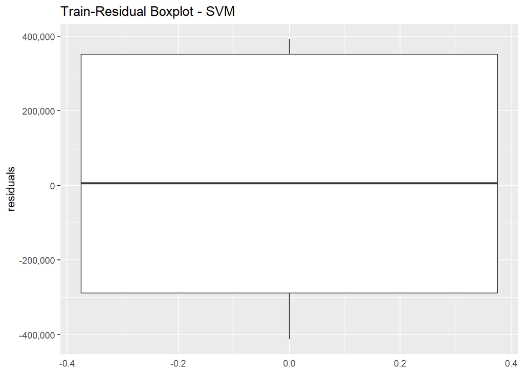

```r
  d_svm <- data.frame(train$Value, tuneResultsvm$best.model$fitted)
  colnames(d_svm) <- c("obs", "pred")
    d_svm$residuals <- tuneResultsvm$best.model$residuals
    limits <- boxplot.stats(x = d_svm$residuals)$stats
    label <- ifelse(d_svm$residuals < limits[1] | d_svm$residuals > limits[5], rownames(d_svm), NA)

  ggplot(d_svm, mapping = aes(y = residuals, x = 0, label = label)) +
      geom_boxplot(orientation = "vertical") +
      labs(title = "Train-Residual Boxplot - SVM") +
      theme(axis.title.x = element_blank(), axis.text.x = element_text(), axis.ticks.x = element_blank())+
      scale_y_continuous(labels = scales::comma)
```

There are no residuals outliers detected in a training dataset.

Checking the residuals outliers for a testing dataset:

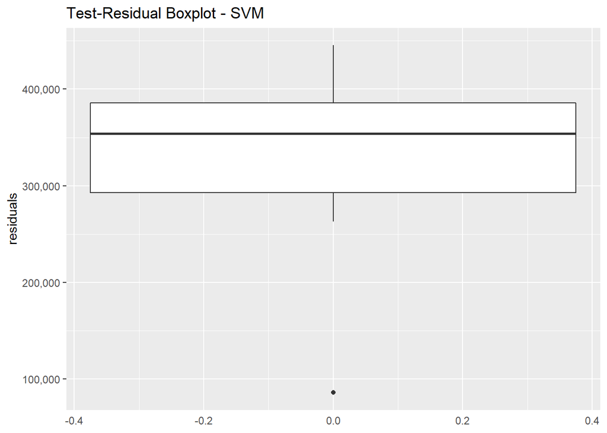

```r
d_svm_test <- data.frame(test$Value, predictYsvm)
 colnames(d_svm_test) <- c("obs", "pred")
   range <- range(c(d_svm_test$obs, d_svm_test$pred), na.rm = TRUE)

   d_svm_test$residuals <- d_svm_test$obs - d_svm_test$pred
    limits <- boxplot.stats(x = d_svm_test$residuals)$stats
    label <- ifelse(d_svm_test$residuals < limits[1] | d_svm_test$residuals > limits[5], rownames(d_svm_test), NA)

   ggplot(d_svm_test, mapping = aes(y = residuals, x = 0, label = label)) +
      geom_boxplot(orientation = "vertical") +
      labs(title = "Test-Residual Boxplot - SVM") +
      theme(axis.title.x = element_blank(), axis.text.x = element_text(), axis.ticks.x = element_blank())+
      scale_y_continuous(labels = scales::comma)
```

There is one residual outlier detected in a testing dataset.

### Cumulative vaccination: Vaccination projection - SVM

Vaccination projection using SVM. We have to create a model using the whole dataset.

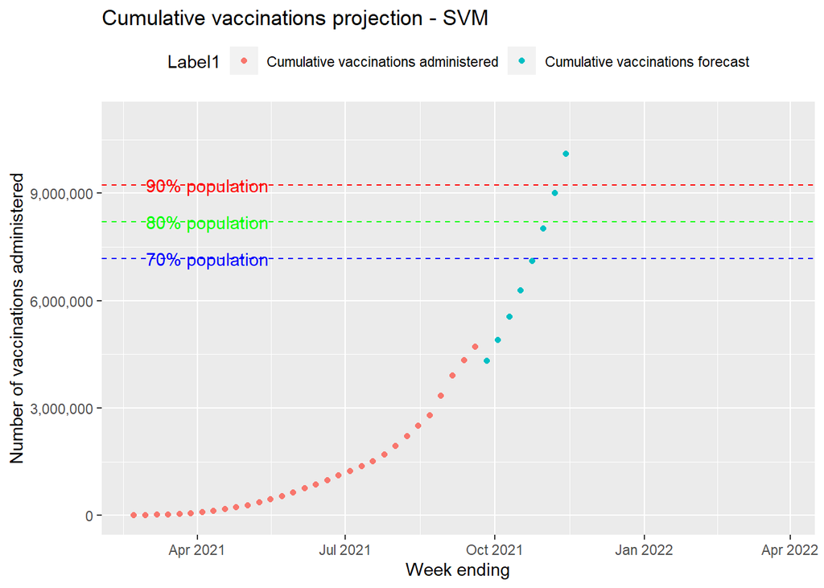

```r
#creating the dataframe for projection
vaccine_prediction_svm <- data.frame(id=1, ResourceID="CPC0V10", Period = c(    # Create example data

                             "2021-09-26",
                             "2021-10-03",
                             "2021-10-10",
                             "2021-10-17",
                             "2021-10-24",
                             "2021-10-31",
                             "2021-11-07",
                             "2021-11-14",
                             "2021-11-21",
                             "2021-11-28",
                             "2021-12-05",
                             "2021-12-12",
                             "2021-12-19",
                             "2021-12-26",
                             "2022-01-02",
                             "2022-01-09",
                             "2022-01-16",
                             "2022-01-23",
                             "2022-01-30",
                             "2022-02-06",
                             "2022-02-13",
                             "2022-02-20",
                             "2022-02-27",
                             "2022-03-06",
                             "2022-03-13",
                             "2022-03-20",
                             "2022-03-27"
                             ),
                   Label1 = "Cumulative vaccinations forecast", Value=0, Unit="Number", Measure="Cumulative Vaccinations", Multiplier=0)
vaccine_prediction_svm$Period <- as.Date(vaccine_prediction_svm$Period,             # Change class of date column
                      format = "%Y-%m-%d")
vaccine_prediction_svm$Period_Num<-as.numeric(vaccine_prediction_svm$Period)
vaccine_prediction_svm<-vaccine_prediction_svm[order(vaccine_prediction_svm$Period),]


#creating the model using the whole dataset
#svm_model <- svm(Value ~ Period , gamma=gammaBest, epsilon=epsilonBest, cost=costBest, kernel = "polynomial", vaccin_adm)


tuneResultsvm_ <- tune(svm, Value ~ Period,  data = vaccin_adm, kernel = "polynomial",
              ranges = list(gamma=2^(-1:1), epsilon = seq(0,1,0.1), cost = 2^(seq(0.5,10,.5))))
#best model selection
svm_model <-tuneResultsvm_$best.model


vaccine_prediction_svm$Value <- predict(svm_model, vaccine_prediction_svm)

#plot the data
library(ggplot2)
library("ggrepel")
ggplot()+
  geom_point(data=vaccin_adm, aes(x=Period, y = Value, group=Label1, colour=Label1)) +
  geom_point(data=vaccine_prediction_svm, aes(x=Period, y = Value, group=Label1, colour=Label1))+
  geom_hline(yintercept=7171640, linetype="dashed", color = "blue")+
  annotate("text",x = as.Date("2021-04-07"), y = 7171640, label = "70% population", color = "blue")+
  geom_hline(yintercept=8196160, linetype="dashed", color = "green")+
  annotate("text",x = as.Date("2021-04-07"), y = 8196160, label = "80% population", color = "green")+
  geom_hline(yintercept=9220680, linetype="dashed", color = "red")+
  annotate("text",x = as.Date("2021-04-07"), y = 9220680, label = "90% population", color = "red")+
  scale_y_continuous(limits=c(0,11000000), labels = scales::comma)+
  ggtitle("Cumulative vaccinations projection - SVM")+
  xlab("Week ending") +
  ylab("Number of vaccinations administered")+
  labs(fill = "1")+
  theme(legend.position="top")
```

The NZ population is 5,122,600 people which means to vaccinate 100% population the 10,245,200 vaccines should be administered. As per our projection using SVM:

-70% population will be vaccinated at the end of October;

-80% population will be vaccinated early November;

-90% population will be vaccinated in the middle of November.

SVM performs well for our dataset.

P.S. In my presentation in the class I used the dataset up to September 2021 and SVM model was showing a strong overfitting. This is why I decided to try another method - Polynomial Regression. I have updated the dataset downloaded from Stats NZ with 3 more dates 5/09/2021, 12/09/2021, 19/09/2021. Data for that dates have been taken from the Ministry of Health website. The main issue is the dataset is very small - we have just 24 observations in our training dataset ans 7 in testing that is why our model is so sensitive to a new data. Below is a vaccination projection using Polynomial Regression.

### Cumulative vaccination: Vaccination forecast using Polynomial Regression method

For Polynomial Regression I will find the optimal coefficient for the training dataset and check how the model performs on the testing dataset. Polynomial regression works on any size of the dataset and works well on non-liner problems. The main challenge is choosing the right polynomial degree for good bias-variance tradeoff.

```r
#train model
Result_lm <- lm(Value ~ poly(Period_Num,2), data=train)
summary(Result_lm)
```

```
##
## Call:
## lm(formula = Value ~ poly(Period_Num, 2), data = train)
##
## Residuals:
##    Min     1Q Median     3Q    Max
## -65399  -3084   4456   7720 111149
##
## Coefficients:
##                      Estimate Std. Error t value Pr(>|t|)
## (Intercept)            613529       6682   91.82   <2e-16 ***
## poly(Period_Num, 2)1  2855280      32734   87.23   <2e-16 ***
## poly(Period_Num, 2)2   953920      32734   29.14   <2e-16 ***
## ---
## Signif. codes:  0 '***' 0.001 '**' 0.01 '*' 0.05 '.' 0.1 ' ' 1
##
## Residual standard error: 32730 on 21 degrees of freedom
## Multiple R-squared:  0.9975, Adjusted R-squared:  0.9973
## F-statistic:  4229 on 2 and 21 DF,  p-value: < 2.2e-16
```

```r
#predict using testing dataset
predictYlm <- predict(Result_lm, test)
```